# Workshop Genome Wide CNVs in the UKB

Simone Montalbano

# Data and libraries

## Libs

Load necessary libraries and CNValidatron package.

```r
library(data.table)
library(ggplot2)
```

```r
# load the package, it will require additional installations
setwd('../CNValidatron_fl')
devtools::load_all()
```

```
## ℹ Loading CNValidatron
```

```r
setwd('../NSHG_CNVs_workshop_2024')
```

```r
# alternatively, just load the functions we use
# way less safe and far from optimal but should work
list.files('../CNValidatron_fl/R')
for (f in list.files('../CNValidatron_fl/R'))
  source(paste0('../CNValidatron_fl/R/', f))
```

# CNV table

Load CNVs data.table.

```r
cnvs <- fread('cnvs.tsv')
```

# Exploratory analysis

## CNV table format

The table we loaded contains all the minimal information to define a set of CNVs, chromosome, start, end, genotype (GT) and/or Copy Number (CN), and sample ID.

```r
cnvs[1:5]
```

```
##    sample_ID   chr  start    end    GT    CN numsnp
##        <int> <int>  <int>  <int> <int> <int>  <int>
## 1:   2159326     1 729632 850780     1     1     22
## 2:   5156417     1 779322 862124     1     1     16
## 3:   4270056     1 772927 984971     1     1     88
## 4:   4201206     1 881627 985900     2     3     59
## 5:   3132954     1 729632 986443     2     3    100
```

## Visualise CNVs, export BED file for IGV

IGV is probably the best tool to visualise CNVs. It can get complex with high number, but we’ll show ways to simplify that. The most basic file format compatible with IGV is the BED4. We can use this format to visualise a sample of our CNV table.

```r
# a minimal BED4 requires chr, start, end and ID. Tab as separator and
# no header
fwrite(cnvs[sample(1:.N, 10000), .(chr, start, end, GT)],
       'cnvs_sample.bed', sep ='\t', col.names = F)
fwrite(cnvs[, .(chr, start, end, GT)],
       'cnvs.bed', sep ='\t', col.names = F)
```

## Length and number of SNPs

One of the first thing we can explore are the CNVs length and number of SNPs distributions. Length is correlated to the number of SNPs but not perfectly, this is because the SNP density is not constant across the array.

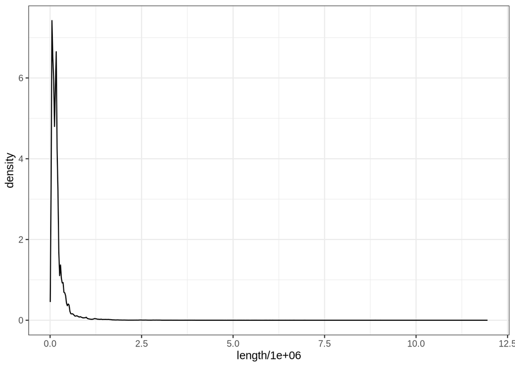

```r
cnvs[, length := end - start + 1]
cnvs[, centre := round(start + length/2)]

# Length is easier to visualize in Mbp
ggplot(cnvs) + geom_density(aes(x = length/1000000)) + theme_bw()
```

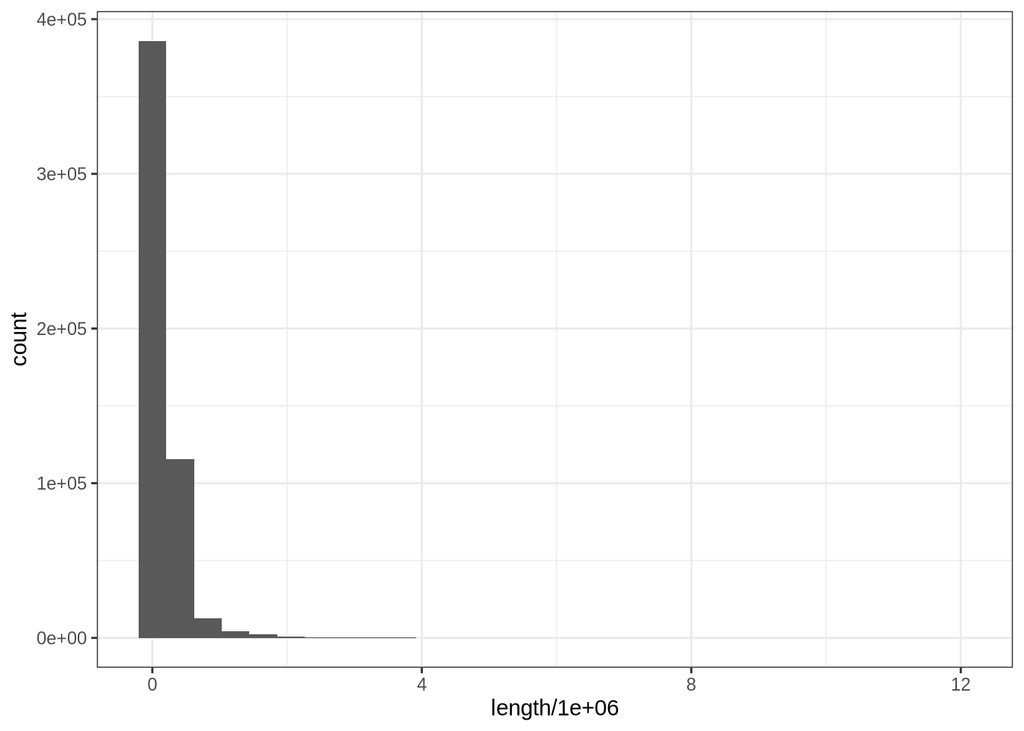

```r
ggplot(cnvs) + geom_histogram(aes(x = length/1000000)) + theme_bw()
```

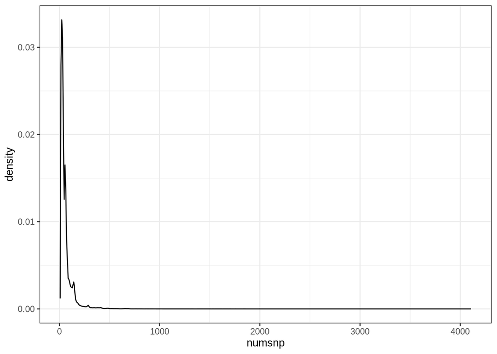

```r
ggplot(cnvs) + geom_density(aes(x = numsnp)) + theme_bw()
```

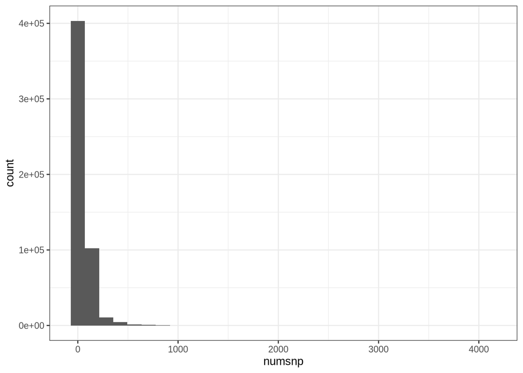

```r
ggplot(cnvs) + geom_histogram(aes(x = numsnp)) + theme_bw()
```

Both distributions have a very long tail that compress most information on the left. We can filter extreme value or use the logarithm.

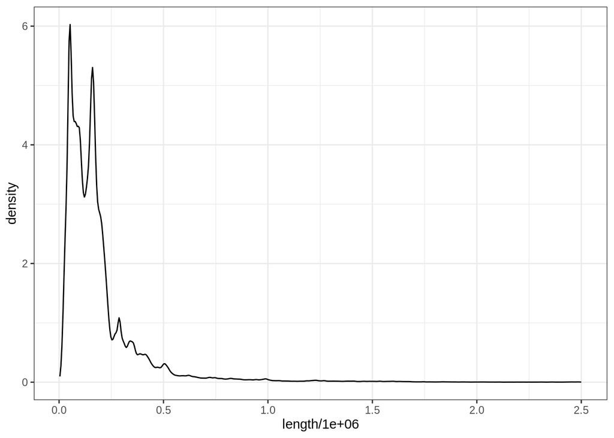

```r
# filter out CNVs larger than 2.5Mbp
ggplot(cnvs[length <= 2500000]) +
  geom_density(aes(x = length/1000000)) + theme_bw()
```

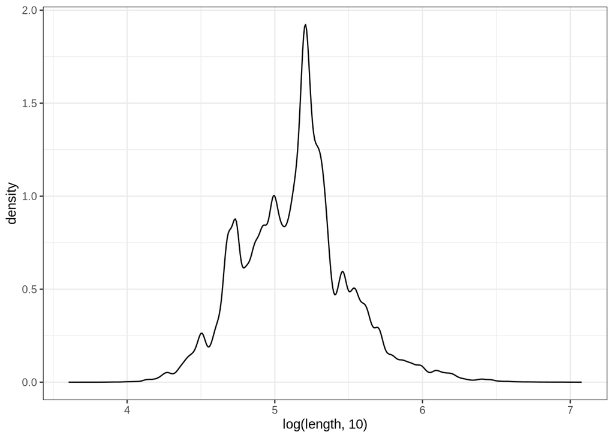

```r
# take the log
ggplot(cnvs) + geom_density(aes(x = log(length, 10))) + theme_bw()
```

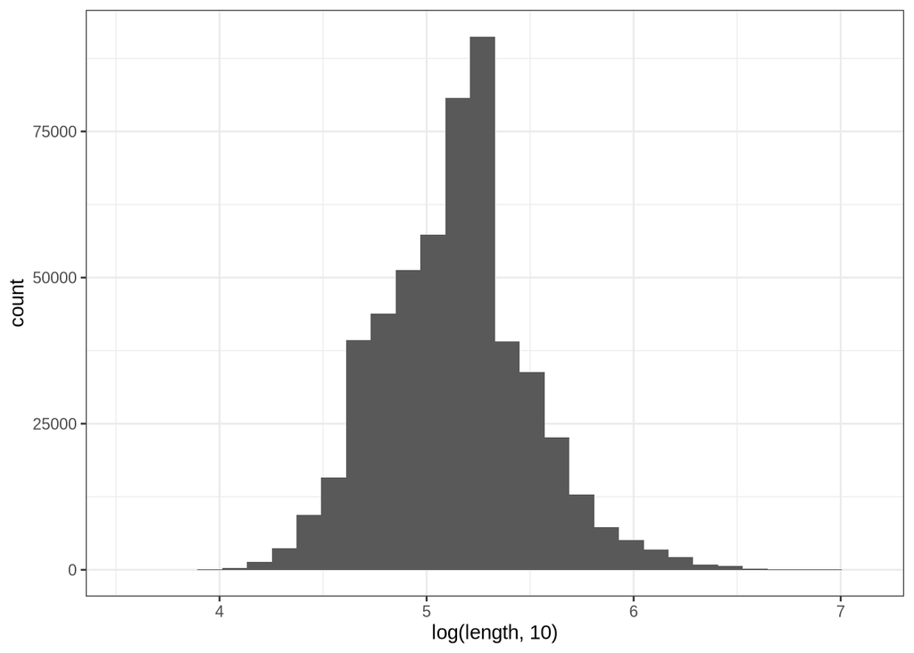

```r
ggplot(cnvs) + geom_histogram(aes(x = log(length, 10))) + theme_bw()
```

Log10 is better and we don’t need to exclude any CNV.

## Differences between deletions and duplications?

Now we can do the same but separate deletions and duplications in order to see if there are differences in the distributions.

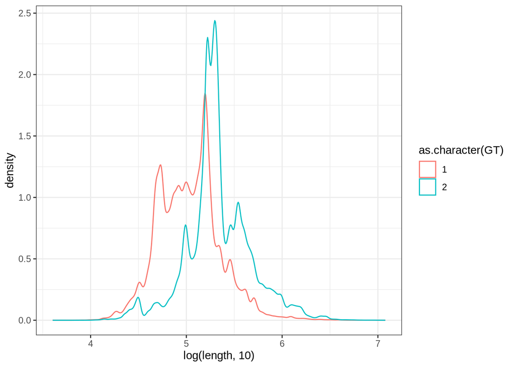

```r
ggplot(cnvs) +
  geom_density(aes(x = log(length, 10), colour = as.character(GT)), alpha = 0.5) +
  theme_bw()
```

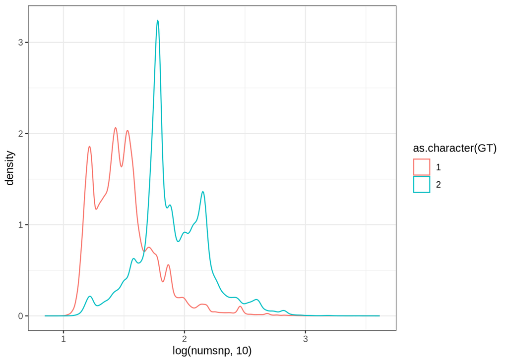

```r
ggplot(cnvs) +
  geom_density(aes(x = log(numsnp, 10), colour = as.character(GT)), alpha = 0.5) +
  theme_bw()
```

Before interpreting any results, remember this is simulated data. However it is simulated from real CNVs, and these results follows what we usually see. Duplication tends to be larger than deletions and the distributions are not as smooth as one might expect.

## CNVs density across the genome

We can have an idea of how CNVs are distributed across the chromosomes using the centre position.

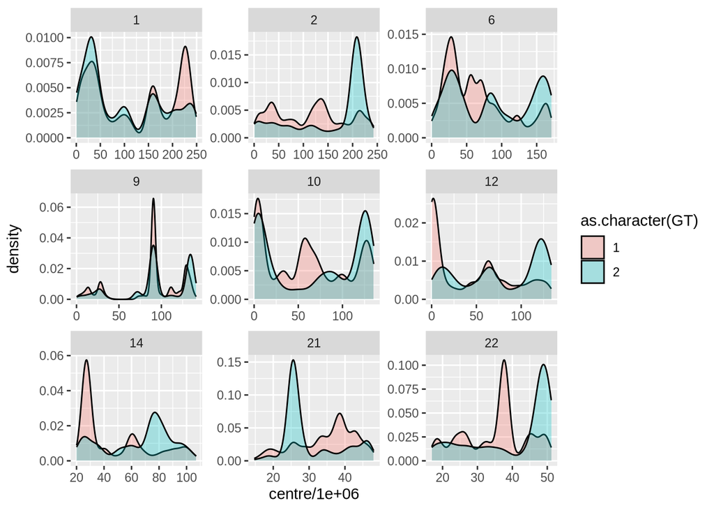

```r
ggplot(cnvs[chr %in% c(1, 2, 6, 9, 10, 12, 14, 21, 22), ]) +
  geom_density(aes(x = centre/1000000, fill = as.character(GT)), alpha = 0.3) +
  facet_wrap(~chr, scales = 'free')
```

I selected a handful of chromosomes that have similar outputs to “the real thing” in this specific simulation.

# How to analyse Genome Wide CNVs

As you might have imagined from the IGV session, CNVs can be a tricky class of variants to analyse. Their size spans from tens kilobases to few megabases and their boundaries can vary a lot even among “similar” CNVs.

There are two main approaches to solve this problem. Use some kind of bins of the genome, such as regular windows or genes, or compute CNV regions (CNVRs). In this section we will cover both approaches.

## Binning the genome

```r
dt <- binned_cnvs(cnvs, format = 'count', bins = CNValidatron:::binned_genome(bin_size = 250000))
saveRDS(dt, 'binned_cnvs_250kbp.rds')
dt <- binned_cnvs(cnvs, format = 'count', bins = CNValidatron:::binned_genome(bin_size = 100000))
saveRDS(dt, 'binned_cnvs_100kbp.rds')
```

## CNVRs

```r
dt <- cnvrs_iou(cnvs, QCtreeCNV::hg19_chr_arms, min_iou = 0.50,
                max_force_merge_rounds = 5, force_merge_min_overlap = 0.75)

saveRDS(dt, 'cnvrs.rds')
fwrite(dt[[1]], 'cnvs_with_cnvrs.txt', sep = '\t')
fwrite(dt[[2]], 'cnvrs.txt', sep = '\t')
```

# What about genes?

## Access Ensembl using biomaRt

## Genomic enrichment analysis